# Episode I: The QC Menace

Peter Fiorica

August 2, 2019

# Introduction

If you are coming to this file from the preQC file, we will be starting with `/home/peter/prostate_cancer/genotypes_dbGaP/preQC_bfiles` as the genotype files we will begin QC with. There is a total of 4769 individuals (2463 cases and 2306 controls) in the cohort that are both male and have phenotypes.

# Quality Control

## QC Step 0: Sex and heterozygous halpoid check

```
plink --bfile /home/peter/prostate_cancer/genotypes_dbGaP/preQC_bfiles --set-hh-missing --make-bed --out /home/peter/prostate_cancer/QC_Steps/step0/qcstep0nohh

plink --bfile /home/peter/prostate_cancer/QC_Steps/step0/qcstep0nohh --check-sex --missing --out /home/peter/prostate_cancer/QC_Steps/step0/qcstep0sexcheck
#We generated a missingness file here with the --missing flag, but we are going to do without the sex check.
```

## QC Step 1: Identifying Unfiltered Genotyping Rate

```
plink --bfile /home/peter/prostate_cancer/QC_Steps/step0/qcstep0nohh --missing --out /home/peter/prostate_cancer/QC_Steps/step1/qcstep1
```

### QC Step 1A: Plotting Unfiltered Genotyping Rate

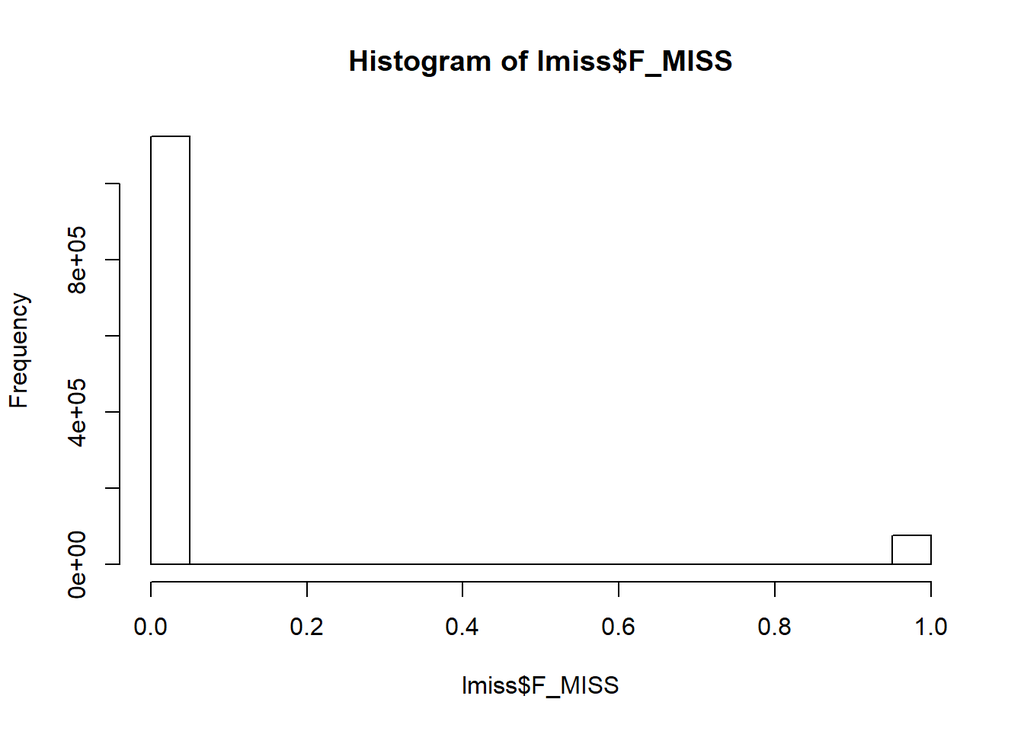

```r
library(ggplot2)
library(dplyr)
library(data.table)
"%&%"=function(a,b) paste(a,b,sep="")
my.dir<-"Z://prostate_cancer/QC_Steps/"
lmiss<-fread(my.dir%&%"step1/qcstep1.lmiss",header = T)
hist(lmiss$F_MISS) #This creates a histogram of the missingness of the data before we filter by genotyping rate.
```

```r
dim(lmiss)[1] #This tells us the number of SNPs we are working with before filtering by genotyping rate
```

```
## [1] 1199187
```

```r
table(lmiss$F_MISS<0.01)
```

```
##
##   FALSE    TRUE
##  115233 1083954
```

```r
table(lmiss$F_MISS<0.02)
```

```
##
##   FALSE    TRUE
##   86889 1112298
```

```r
sum(lmiss$F_MISS<0.01)/(dim(lmiss)[1])
```

```
## [1] 0.9039074
```

```r
sum(lmiss$F_MISS<0.02)/(dim(lmiss)[1])#The percent of SNPs have a genotyping call rate of 98%
```

```
## [1] 0.9275434
```

There are 1083954 SNPs that meet a genotyping rate of 0.99 and 1112298 SNPs that meet a genotyping rate of 0.98

## QC Step 2: Filtering SNPs by Genotyping Rate

```
plink --bfile /home/peter/prostate_cancer/QC_Steps/step0/qcstep0nohh --geno 0.01 --make-bed --out /home/peter/prostate_cancer/QC_Steps/step2/qcstep2
```

## QC Step 3: Identifying Filtered Genotyping Rate

```
plink --bfile /home/peter/prostate_cancer/QC_Steps/step2/qcstep2 --missing --out /home/peter/prostate_cancer/QC_Steps/step3/qcstep3
```

### QC Step 3A: Plotting Filtered Genotyping Rate

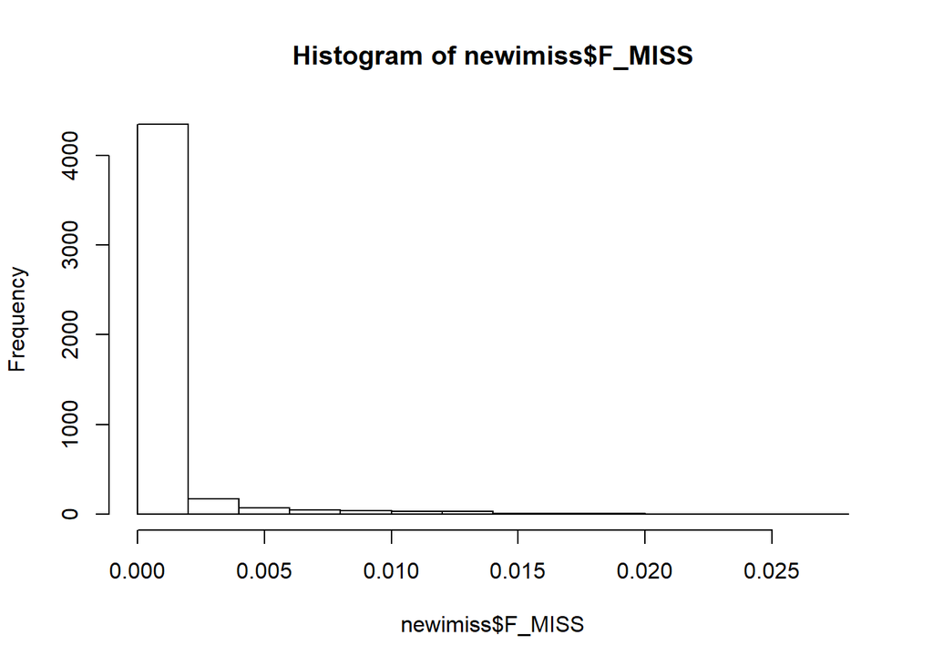

```r
newimiss<-fread(my.dir%&%"step3/qcstep3.imiss")
hist(newimiss$F_MISS)
```

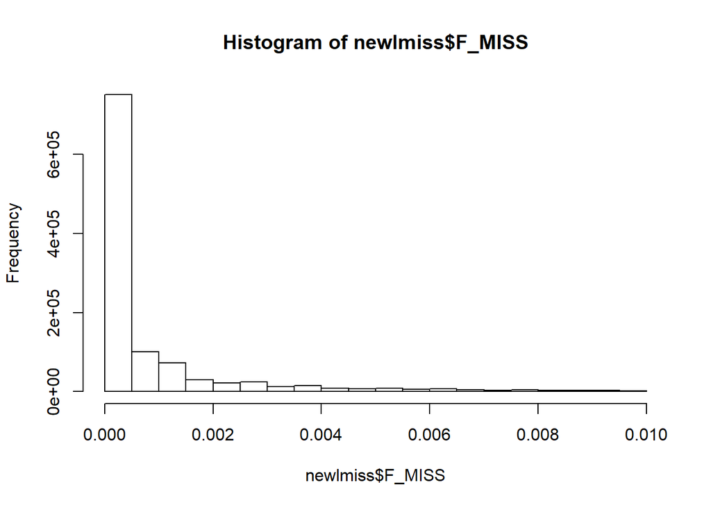

```r
newlmiss<-fread(my.dir%&%"step3/qcstep3.lmiss")
hist(newlmiss$F_MISS)
```

```r
dim(newlmiss)[1]
```

```
## [1] 1083954
```

## QC Step 4: Filtering by HWE

```
plink --bfile /home/peter/prostate_cancer/QC_Steps/step2/qcstep2 --hardy --out /home/peter/prostate_cancer/QC_Steps/step4/qcstep4
```

### QC Step 4A: Plotting HWE Frequencies and Removing SNPs outside of HWE

We need to remove SNPs that are outside of HWE (P<1e-6)

```r
hwe<-fread(my.dir%&%"step4/qcstep4.hwe",header =T)
summary(hwe$P)
```

```
##    Min. 1st Qu.  Median    Mean 3rd Qu.    Max.
##  0.0000  0.2281  0.5299  0.5324  0.8475  1.0000
```

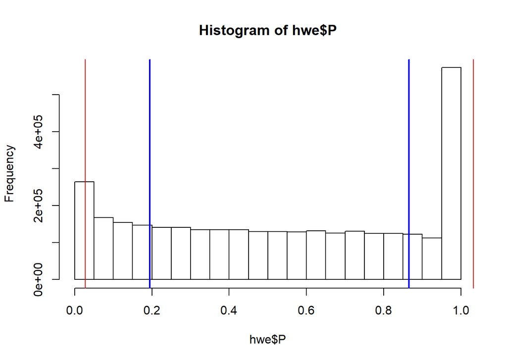

```r
hist(hwe$P)
abline(v = median(hwe$P)+sd(hwe$P), col = "blue", lwd = 2)
abline(v = median(hwe$P)-sd(hwe$P), col = "blue", lwd = 2)
abline(v = median(hwe$P)+1.5*sd(hwe$P), col = "red")
abline(v = median(hwe$P)-1.5*sd(hwe$P), col = "red")
```

```r
table(hwe$P<1e-06)
```

```
##
##   FALSE    TRUE
## 3238970   12892
```

```r
table(hwe$P<1e-06)/sum(table(hwe$P<1e-06))
```

```
##
##       FALSE        TRUE
## 0.996035502 0.003964498
```

```r
outlierSNPs<-as.data.table(subset(hwe$SNP,hwe$P<=1e-6))
fwrite(outlierSNPs, my.dir%&%"step4/HWEoutlierSNPstoberemoved.txt", col.names = F, row.names = F, sep = " ", quote = F)
```

### QC Step 4B: Removing Outlier SNPs

```
plink --bfile /home/peter/prostate_cancer/QC_Steps/step2/qcstep2 --exclude /home/peter/prostate_cancer/QC_Steps/step4/HWEoutlierSNPstoberemoved.txt --make-bed --out  /home/peter/prostate_cancer/QC_Steps/step4/qcstep4b
```

## QC Step 5: IBD Pruning

### QC Step 5a: Calculating IBD values

```
plink --bfile /home/peter/prostate_cancer/QC_Steps/step4/qcstep4b --indep-pairwise 50 5 0.3 --out /home/peter/prostate_cancer/QC_Steps/step5/step5a/QCStep5a
```

### QC Step 5b: Extracting SNPs with excess IBD

```
plink --bfile /home/peter/prostate_cancer/QC_Steps/step4/qcstep4b --extract /home/peter/prostate_cancer/QC_Steps/step5/step5a/QCStep5a.prune.in --genome --min 0.05 --out /home/peter/prostate_cancer/QC_Steps/step5/step5b/QCStep5b
```

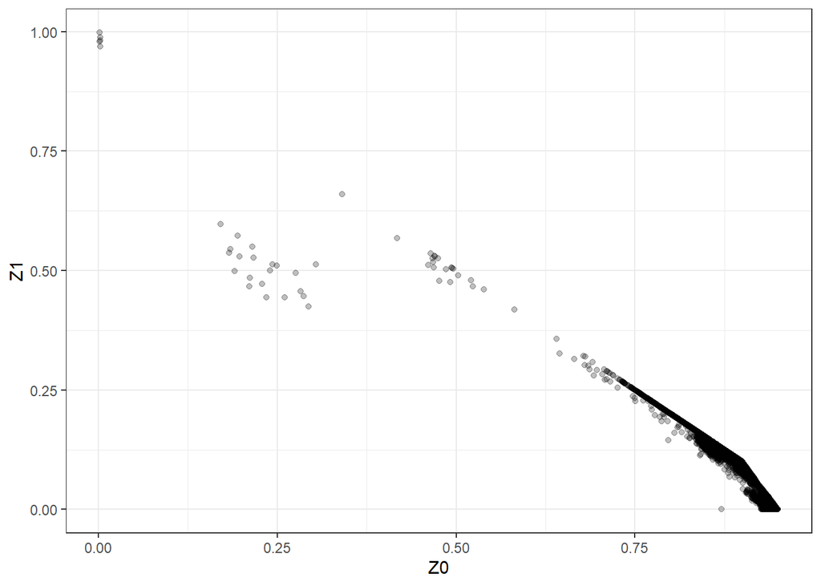

```r
ibd<-fread(my.dir %&% "step5/step5b/QCStep5b.genome",header=T)
ggplot(data = ibd, aes(x=Z0,y=Z1))+geom_point(alpha=1/4)+theme_bw()
```

```r
#We have some parents, siblings, and other related in this data that we will need to remove.  For explanation, see Figure 4 of Turner et al. Current Protoc Hum Genet (2011)."
##Now we can check for duplicates in the data
dups<-data.frame()
for( i in 1:dim(ibd)[1]){
  if(as.character(ibd$IID1[i])==as.character(ibd$IID2[i])){
    dups<-rbind(dups,ibd[i,])
  }
}
dim(dups)
```

```
## [1] 0 0
```

```r
hapmap <- filter(ibd,grepl('NA',IID1))
#No hapmap individuals. No surpise.
toExclude <- c(as.character(dups$IID1),as.character(hapmap$IID1))
a <- as.character(ibd$IID1) %in% toExclude
others <- ibd[a==FALSE,]
#Isolating individuals that need to be removed.
toremove<-filter(others,PI_HAT>=0.2)
write.table(toremove,my.dir%&%"step5/step5b/Relate.to.remove.txt",quote=FALSE, row.names = FALSE)
```

### QC Step 5C: Identifying individuals with excess heterozygosity

```
plink --bfile /home/peter/prostate_cancer/QC_Steps/step4/qcstep4b --extract /home/peter/prostate_cancer/QC_Steps/step5/step5a/QCStep5a.prune.in --het --out QCStep5c
```

### Plotting Heterozygosity Data

```r
HET<-fread(my.dir%&%"step5/step5c/QCStep5c.het",header =T)
h=HET$"N(NM)"-HET$"O(HOM)"/HET$"N(NM)"
oldpar = par(mfrow=c(1,2))
hist(h,50)
hist(HET$F,50)
summary(HET$F)
```

```
##      Min.   1st Qu.    Median      Mean   3rd Qu.      Max.
## -0.093250 -0.009631  0.005951  0.005602  0.020400  0.190600
```

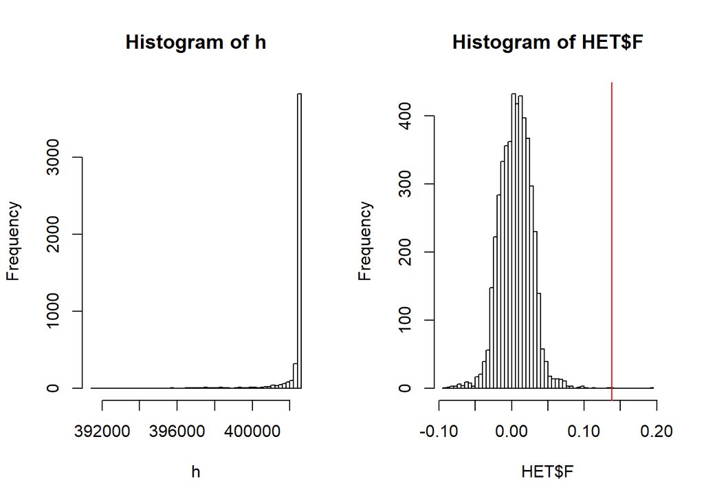

```r
abline(v=mean(HET$F)+6*sd(HET$F),col="red")
abline(v=mean(HET$F)-6*sd(HET$F),col="red")
```

```r
sortHET <- HET[order(HET$F),]
outliers <- data.table()

for(i in 1:length(sortHET$F)){
  if(sortHET[i,6] > (mean(sortHET$F)+3*sd(sortHET$F))){
    outliers <- rbind(outliers, sortHET[i,])
  }
  if(sortHET[i,6] < (mean(sortHET$F)-3*sd(sortHET$F))){
    outliers <- rbind(outliers, sortHET[i,])
  }
}

hetoutliers <- select(outliers, FID, IID)
dim(hetoutliers) #This tells us how many outliers there are.
```

```
## [1] 50  2
```

```r
fwrite(hetoutliers, "Z://prostate_cancer/QC_Steps/step5/step5c/hetoutliers.txt", quote = F, col.names = F, row.names = F, sep = " ")
```

### QC Step 5D: Removing Heterozygosity Outliers

```
plink --bfile /home/peter/prostate_cancer/QC_Steps/step4/qcstep4b --remove /home/peter/prostate_cancer/QC_Steps/step5/step5c/hetoutliers.txt --extract /home/peter/prostate_cancer/QC_Steps/step5/step5a/QCStep5a.prune.in --make-bed --out /home/peter/prostate_cancer/QC_Steps/step5/step5d/QCStep5d

plink --bfile /home/peter/prostate_cancer/QC_Steps/step5/step5d/QCStep5d --extract /home/peter/prostate_cancer/QC_Steps/step5/step5a/QCStep5a.prune.in --remove /home/peter/prostate_cancer/QC_Steps/step5/step5b/Relate.to.remove.txt --genome --min 0.05 --out QCStep5D
```

### Plotting IBD Filtered Data:

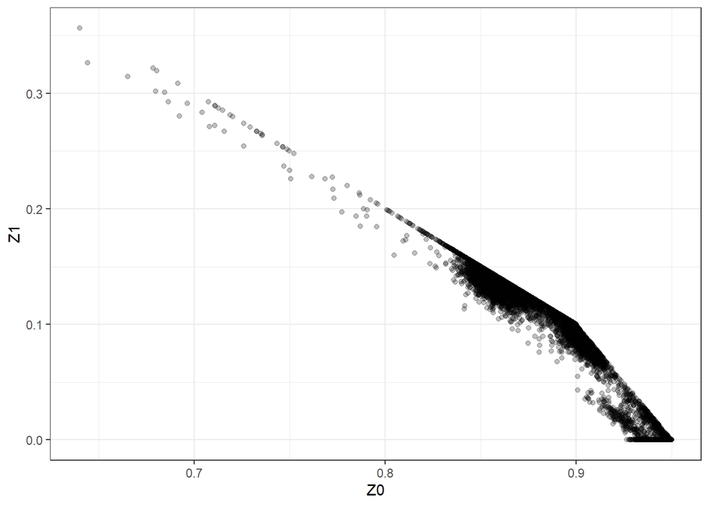

```r
IBD<-fread(my.dir %&% "step5/step5d/QCStep5D.genome",header=T)
ggplot(data = IBD, aes(x=Z0,y=Z1))+geom_point(alpha=1/4)+theme_bw()
```

### QC Step 5E: Second Heterozygosity Check

```
plink --bfile /home/peter/prostate_cancer/QC_Steps/step5/step5d/QCStep5d --het --out /home/peter/prostate_cancer/QC_Steps/step5/step5e/QCStep5e
```

```r
HET<-fread(my.dir%&%"/step5/step5e/QCStep5.het",header =T)
h=HET$"N(NM)"-HET$"O(HOM)"/HET$"N(NM)"
oldpar = par(mfrow=c(1,2))
hist(h,50)
hist(HET$F,50)
summary(HET$F)
```

```
##      Min.   1st Qu.    Median      Mean   3rd Qu.      Max.
## -0.060470 -0.009887  0.005533  0.005187  0.019810  0.071000
```

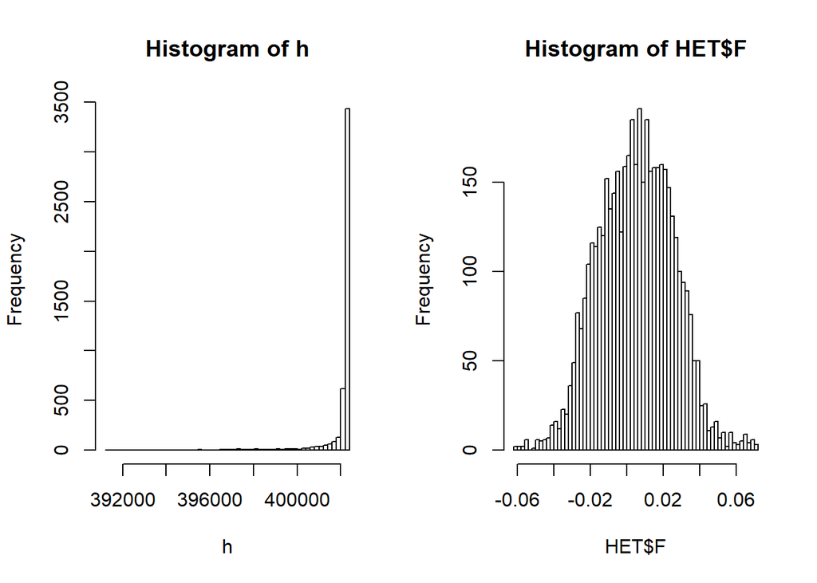

```r
abline(v=mean(HET$F)+6*sd(HET$F),col="red")
abline(v=mean(HET$F)-6*sd(HET$F),col="red")
```

```r
sortHET <- HET[order(HET$F),]
outliers <- data.table()

for(i in 1:length(sortHET$F)){
  if(sortHET[i,6] > (mean(sortHET$F)+3*sd(sortHET$F))){
    outliers <- rbind(outliers, sortHET[i,])
  }
  if(sortHET[i,6] < (mean(sortHET$F)-3*sd(sortHET$F))){
    outliers <- rbind(outliers, sortHET[i,])
  }
}

hetoutliers <- select(outliers, FID, IID)
dim(hetoutliers)
```

```
## [1] 18  2
```

```r
#These outliers are individuals from the data that was after we removed the initial outliers.  This would be too stringent to remove these outliers.
```

### QC Step 5F

[output not shown]

## QC Step 6: Principal Component Analysis

### QC Step 6A: Merge with HapMap

```
plink --bfile /home/peter/prostate_cancer/QC_Steps/step5/step5f/QCStep5f --bmerge /home/wheelerlab1/Data/HAPMAP3_hg18/HM3_ASN_CEU_YRI_Unrelated_hg18_noAmbig --make-bed --out /home/peter/prostate_cancer/QC_Steps/step6/step6a/step6a
```

### QC Step 6B: Exclude Missing SNPs or SNPs with 3+ Alleles

```
plink  --bfile /home/wheelerlab1/Data/HAPMAP3_hg18/HM3_ASN_CEU_YRI_Unrelated_hg18_noAmbig --exclude /home/peter/prostate_cancer/QC_Steps/step6/step6a/step6a-merge.missnp --make-bed --out /home/peter/prostate_cancer/QC_Steps/step6/step6b/step6b
```

### QC Step6C: Merge Attempt 2 with Excluded SNPs

```
plink --bfile /home/peter/prostate_cancer/QC_Steps/step5/step5f/QCStep5f --bmerge /home/peter/prostate_cancer/QC_Steps/step6/step6b/step6b --out /home/peter/prostate_cancer/QC_Steps/step6/step6c/step6c
```

### QC Step6D: Run PCA

```
plink --bfile /home/peter/prostate_cancer/QC_Steps/step6/step6c/step6c --geno 0.01 --maf 0.05 --chr 1-22 --pca 10 --out QCStep6D_PCA
```

```r
hapmappopinfo<-read.table(my.dir%&%"step6/pop_HM3_hg18_forPCA.txt")%>%select(V1,V3)
colnames(hapmappopinfo) <- c("pop","IID")

fam <-fread(my.dir%&%"step6/step6c/step6c.fam", header =F)%>%select(V1,V2)
colnames(fam) <- c("FID","IID")

popinfo <- left_join(fam,hapmappopinfo,by="IID")
popinfo <-mutate(popinfo, pop=ifelse(is.na(pop),'GWAS',as.character(pop)))
table(popinfo$pop)
```

```
##
##  ASN  CEU GWAS  YRI
##  170  111 4674  110
```

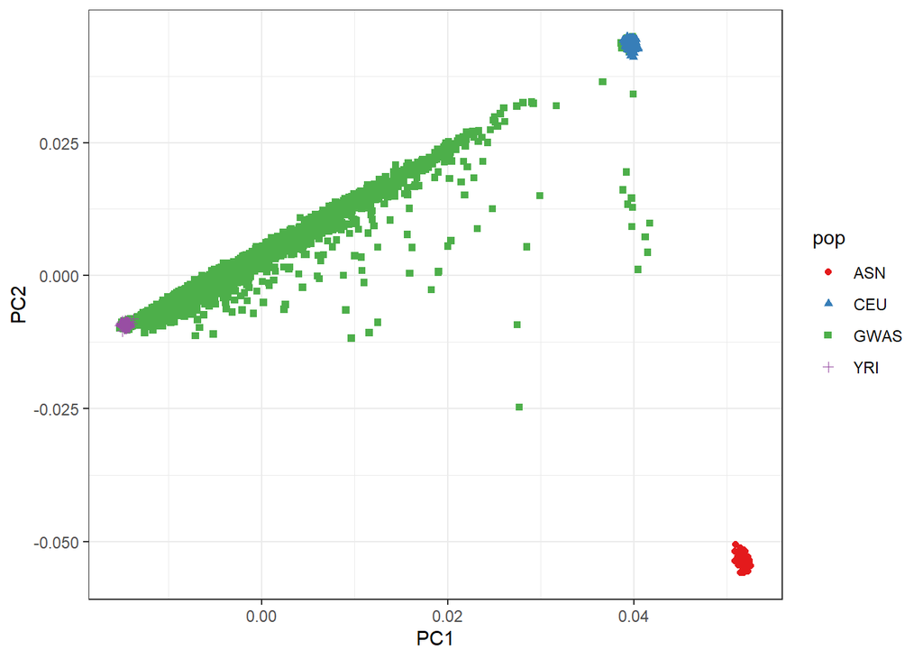

```r
pcs<-read.table(my.dir%&%"step6/QCStep6D_PCA.eigenvec")
pcdf <- data.frame(popinfo, pcs[,3:12]) %>% rename (PC1=V3,PC2=V4,PC3=V5,PC4=V6,PC5=V7,PC6=V8,PC7=V9,PC8=V10,PC9=V11,PC10=V12)
gwas <- filter(pcdf,pop=='GWAS')
hm3 <- filter(pcdf, grepl('NA',IID))
eval<-scan(my.dir%&%"step6/QCStep6D_PCA.eigenval")[1:10]
pve<-eval/sum(eval)#Calculate the percent explained by each PC
PCs<-c(1:10)
PVE<-data.table(PCs,pve)

ggplot() + geom_point(data=gwas,aes(x=PC1,y=PC2,col=pop,shape=pop))+geom_point(data=hm3,aes(x=PC1,y=PC2,col=pop,shape=pop))+ theme_bw() + scale_colour_brewer(palette="Set1")
```

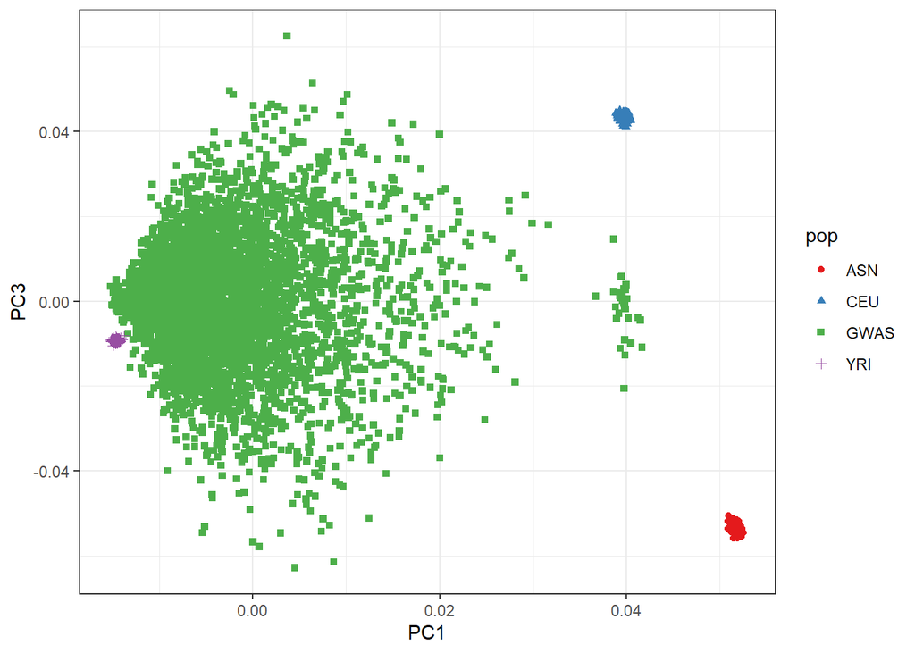

```r
ggplot() + geom_point(data=gwas,aes(x=PC1,y=PC3,col=pop,shape=pop))+geom_point(data=hm3,aes(x=PC1,y=PC2,col=pop,shape=pop))+ theme_bw() + scale_colour_brewer(palette="Set1")
```

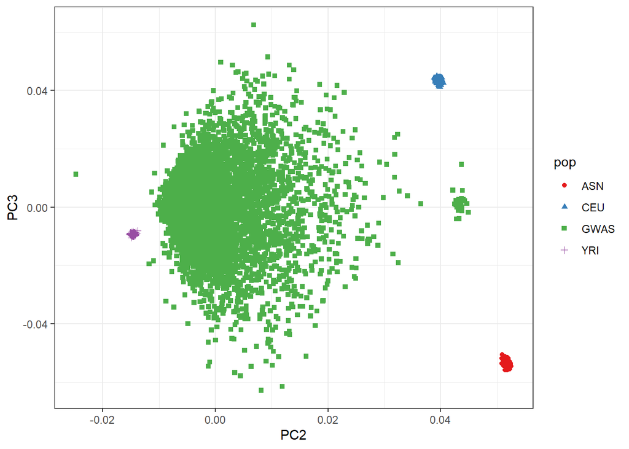

```r
ggplot() + geom_point(data=gwas,aes(x=PC2,y=PC3,col=pop,shape=pop))+geom_point(data=hm3,aes(x=PC1,y=PC2,col=pop,shape=pop))+ theme_bw() + scale_colour_brewer(palette="Set1")
```

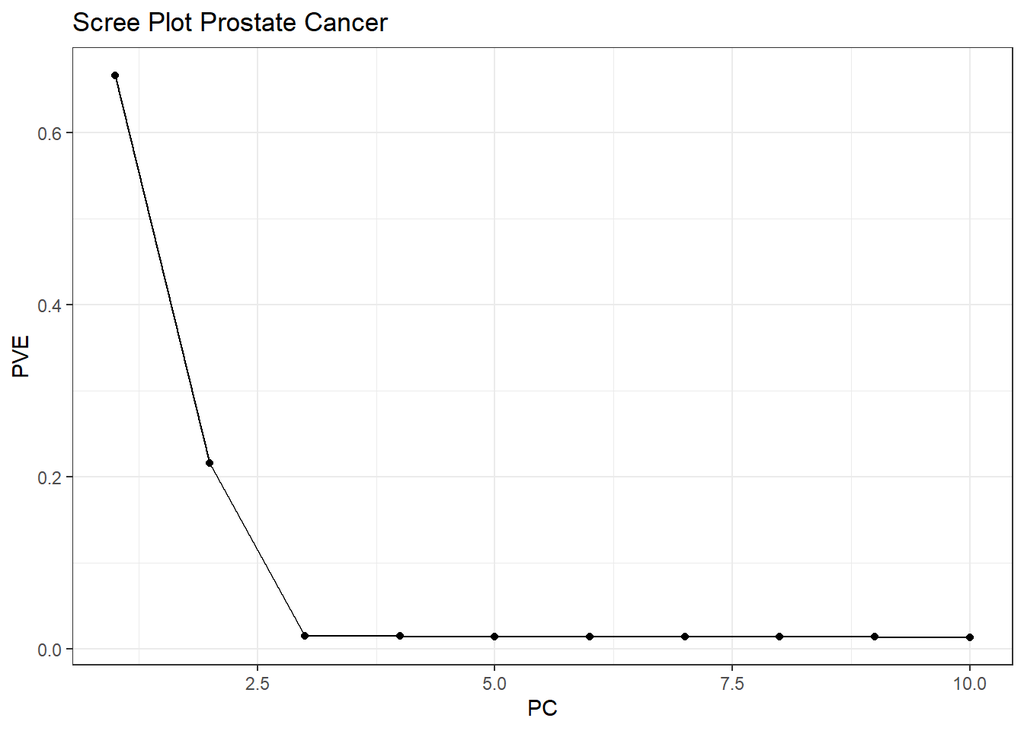

```r
ggplot(data = PVE, aes(y=pve, x = PCs)) + geom_point() + geom_line() + xlab("PC") + ylab("PVE") + ggtitle("Scree Plot Prostate Cancer") + theme_bw()
```

# Next Steps

## Lift Over

Right now, the data is in genome build hg18. We need to lift it over to hg19. A good example of the liftover process can be found at https://github.com/WheelerLab/Neuropsychiatric-Phenotypes/blob/master/SCZ-BD_Px/1_hg18tohg19liftover.md. When we perform the liftover, we will use `home/peter/prostate_cancer/QC_Steps/step4/qcstep4b` since this set of files includes unpruned data with HWE outliers removed.

## Imputation

After liftover, we will upload the data to the [University of Michigan Imputation Server](https://imputationserver.sph.umich.edu/index.html#!). The imputed data will then be filtered to remove SNPs with $r^{2}<0.8$ and MAF < 0.01